# Browns Kicker Analysis (2015)

```r
library(readr)
library(dplyr)
library(ggplot2)
library(data.table)
library(stringr)
library(TeachBayes)
```

Load needed libraries.

```r
kickers <- read_csv("~/Desktop/Browns/Project Data.csv")
```

Read in the data provided by the Browns.

```r
head(kickers)
```

| gamedate | gameseason | week | quarter | down | clock | defscore | gainlossnet | kickyards | noplay | offscore | penaltyyards | returnyards | gameid | sortorder | tricklook | defteam | distance | fieldposition | gainloss | hangtime | hash | kickdepth | kickdiractual | kickdirintended | kicker | kickresult | kicktype | kickwidth | kickzone | … |
| --- | --- | --- | --- | --- | --- | --- | --- | --- | --- | --- | --- | --- | --- | --- | --- | --- | --- | --- | --- | --- | --- | --- | --- | --- | --- | --- | --- | --- | --- | --- |
| 1/7/2006 | 2006 | WC | 1 | 0 | 15:00:00 | 0 | 35 | 63 | 0 | 0 | NULL | 28 | 2006WCNENYJ | 1 | 0 | NYJ | 0 | -30 | 63 | 3.63 | C | 63 | NA | NA | NYJ 01 | RETURNED | D | 43 | 6R | … |
| 1/7/2006 | 2006 | WC | 1 | 0 | 11:53:00 | 0 | 0 | NULL | 0 | 7 | NULL | NULL | 2006WCNENYJ | 12 | 0 | NYJ | 0 | 2 | NULL | NULL | C | NA | NA | NA | NE 03 | MADE - M | NA | NA | NA | … |
| 1/7/2006 | 2006 | WC | 1 | 0 | 11:53:00 | 7 | 31 | 66 | 0 | 0 | NULL | 35 | 2006WCNENYJ | 13 | 0 | NE | 0 | -30 | 66 | 3.62 | C | 66 | NA | NA | NE 03 | RETURNED | D | 13 | 2L | … |
| 1/7/2006 | 2006 | WC | 1 | 4 | 02:39:00 | 7 | 0 | 28 | 0 | 3 | NULL | NULL | 2006WCNENYJ | 37 | 0 | NE | 5 | 10 | 28 | NULL | L | NA | NA | NA | NYJ 01 | MADE - M | NA | NA | NA | … |
| 1/7/2006 | 2006 | WC | 1 | 0 | 02:36:00 | 3 | 40 | 66 | 0 | 7 | NULL | 26 | 2006WCNENYJ | 38 | 0 | NYJ | 0 | -30 | 66 | 3.87 | C | 66 | NA | NA | NYJ 01 | RETURNED | D | 36 | 5R | … |
| 1/7/2006 | 2006 | WC | 2 | 0 | 14:45:00 | 7 | 0 | NULL | 0 | 10 | NULL | NULL | 2006WCNENYJ | 49 | 0 | NE | 0 | 2 | NULL | NULL | L | NA | NA | NA | NYJ 01 | MADE - M | NA | NA | NA | … |

Get a look at the data.

```r
unique(kickers$specialteamstype)
```

```
[1] "KICKOFF"     "EXTRA POINT" "FIELD GOAL"
```

```r
unique(kickers$kickresult)
```

```
 [1] "RETURNED"                  "MADE - M"                  "ONSIDE"
 [4] "MADE - IL"                 "TOUCHBACK"                 "MISSED - WL"
 [7] "MISSED - WR"               "MISSED - B"                "MADE - IR"
[10] "MISSED - S"                "MISSED - HR"               "FAIR CATCH"
[13] "MISSED - HC"               "MISSED - HL"               "MADE"
[16] "OUT OF BOUNDS"             NA                          "MISSED"
[19] "RECOVERED BY KICKING TEAM"
```

See what the different categories of kicks are in the data set.

```r
kickers$week <- as.integer(kickers$week)
kickers <- filter(kickers, !is.na(week))
fg <- filter(kickers, specialteamstype == "FIELD GOAL")
xp <- filter(kickers, specialteamstype == "EXTRA POINT")
ko <- filter(kickers, specialteamstype == "KICKOFF")
```

Separate the data by kick type, exclude pre-season & playoffs (forced NA’s on non-numeric in “week” column)

```r
fg$kickyards <- as.integer(fg$kickyards)
```

```
NAs introduced by coercion
```

```r
fg$Temperature <- as.integer(fg$Temperature)
```

```
NAs introduced by coercion
```

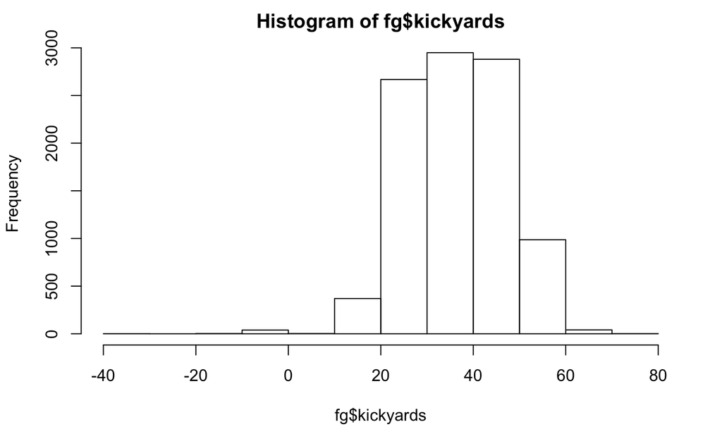

```r
hist(fg$kickyards)
```

First get an idea of the distribution of kicks. Clearly some with negative values are in error.

```r
fg <- filter(fg, kickyards >= 18)
```

Filter out field goal attempts at less than 18 “kickyards”. Need to group the kicks in 5-yard buckets for better illustration.

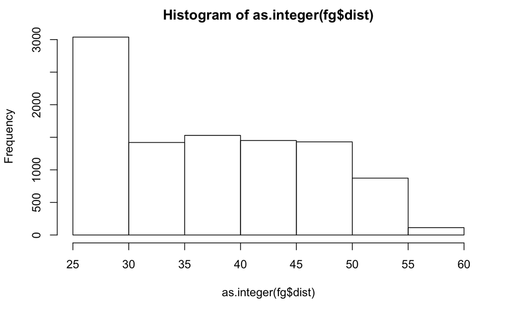

```r
fg$made <- ifelse(grepl("MADE",fg$kickresult), 1, 0) #"made" column is 1 if "MADE" is a substring in kickresults
fg$kickyards <- as.integer(fg$kickyards)
fg$dist <- ifelse(fg$kickyards >= 26,
                  ifelse(fg$kickyards >= 31,
                         ifelse(fg$kickyards >= 36,
                                ifelse(fg$kickyards >= 41,
                                       ifelse(fg$kickyards >= 46,
                                              ifelse(fg$kickyards >= 51,
                                                     ifelse(fg$kickyards >= 56,
                                                            ifelse(fg$kickyards <= 60, 60, NA),
                                                                   55), 50), 45), 40),
                                                                    35), 30), 25)
hist(as.integer(fg$dist), breaks=c(25,30,35,40,45,50,55,60))
```

## Historical Context

Start with field goals. Group into buckets going from 25 then 5-yards buckets up to 60. Anything over 60 is like a desperation attempt. Lots of short FGs (line of scrimmage inside of the 20) and a dramatic drop above 55 yards. s

```r
fg_year <- fg %>%
    group_by(gameseason, dist) %>%
    summarise(fg_per = mean(made)*100)
```

Then groupby year to find the field goal percentage for each yard line

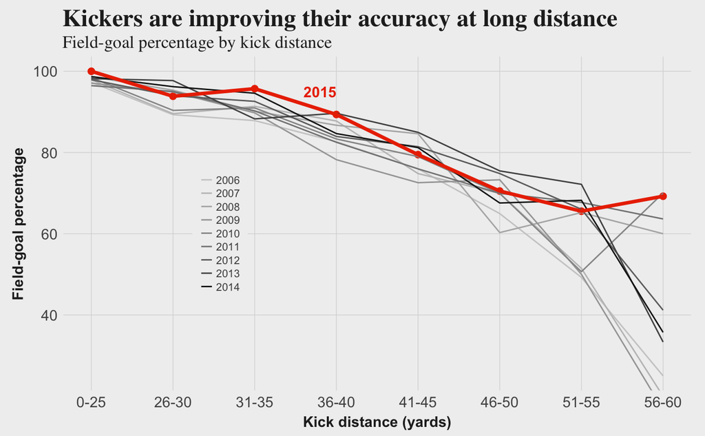

```r
fg_year$season <- as.factor(fg_year$gameseason) #make a factor column for proper legend generation
#Break into two buckets for highlighting 2015
fg_2015 <- filter(fg_year, gameseason == 2015)
fg_2006_2014 <- filter(fg_year, gameseason <= 2014)
ggplot(fg_2006_2014, aes(dist, fg_per)) +
    geom_point(data=fg_2015, color=browns2, size = 2) +
    geom_line(aes(color = season)) +
    geom_line(data=fg_2015, color = browns2, size = 1.25) +
    scale_colour_grey(start=0.8, end=0.1) +
    labs(title = 'Kickers are improving their accuracy at long distance', x='Kick distance (yards)', y='Field-goal percentage', subtitle='Field-goal percentage by kick distance') +
    coord_cartesian(ylim=c(25, 100)) +
    annotate("text", x = 39, y = 95, label = "2015", color = browns2, fontface =2) +
    scale_x_continuous(breaks=seq(25,60,5), labels=c('0-25','26-30','31-35','36-40','41-45','46-50','51-55','56-60'), minor_breaks = NULL) +
    fte_theme() +
    theme(legend.title=element_blank()) +
    theme(legend.position = c(0.25, 0.48)) +
    theme(legend.text = element_text(size=8))
```

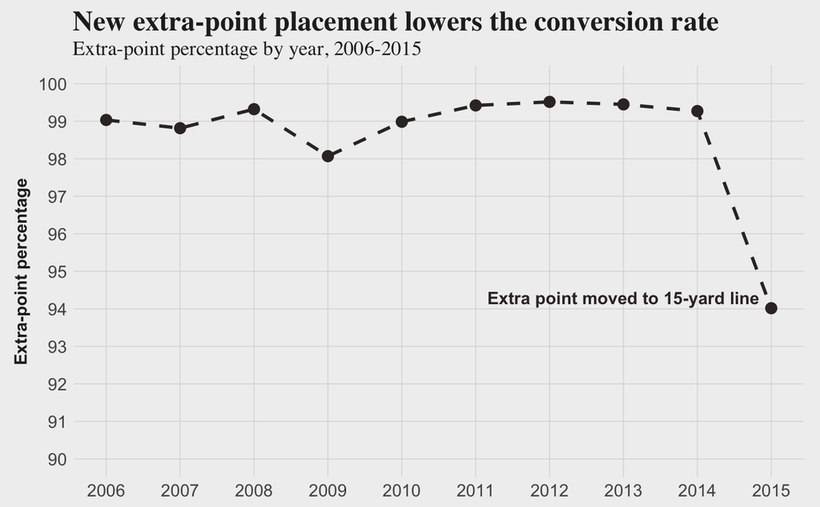

```r
#Extra points by year
xp <- xp %>%
    filter(!is.na(kickresult)) %>%
    mutate(made = ifelse(grepl("MADE", kickresult), 1, 0))
xp_year <- xp %>%
    group_by(gameseason) %>%
    summarise(xp_per = mean(made)*100)
ggplot(xp_year, aes(gameseason, xp_per)) +
    geom_point(color=browns, size = 3) +
    geom_line(linetype=2, color=browns, size = 1) +
    fte_theme() +
    labs(title='New extra-point placement lowers the conversion rate', subtitle='Extra-point percentage by year, 2006-2015', y='Extra-point percentage', x=NULL) +
    scale_x_continuous(breaks = c(seq(2004, 2015, 1))) +
    scale_y_continuous(breaks = c(seq(90, 100, 1))) +
    coord_cartesian(ylim=c(90, 100)) +
    annotate("text", x = 2013, y = 94.3, label = "Extra point moved to 15-yard line", color = browns, fontface =2)
```

Need to calculate historical context for kickoffs, which is proving more difficult. It’s easy to count touchbacks, but average starting field position is harder. The “playendfieldposition” column looks good, but clearly doesn’t include longer returns. The best solution appears to be limiting the “fieldposition” column to traditional kickoff marks (-30, -35) and then calculate ending yards from own goal (yfog) by subtracting that from “kickyards” and adding “returnyards”. The results for that calculation look most realistic. Also filter for “ONSIDE”, “FAIR CATCH” and “RECOVERED BY KICKING TEAM” to make it as close to regular kicking situations as possible.

```r
ko$returnyards <- as.numeric(ko$returnyards) #change from character
```

```
NAs introduced by coercion
```

```r
ko$kickyards <- as.numeric(ko$kickyards) #change from character
```

```
NAs introduced by coercion
```

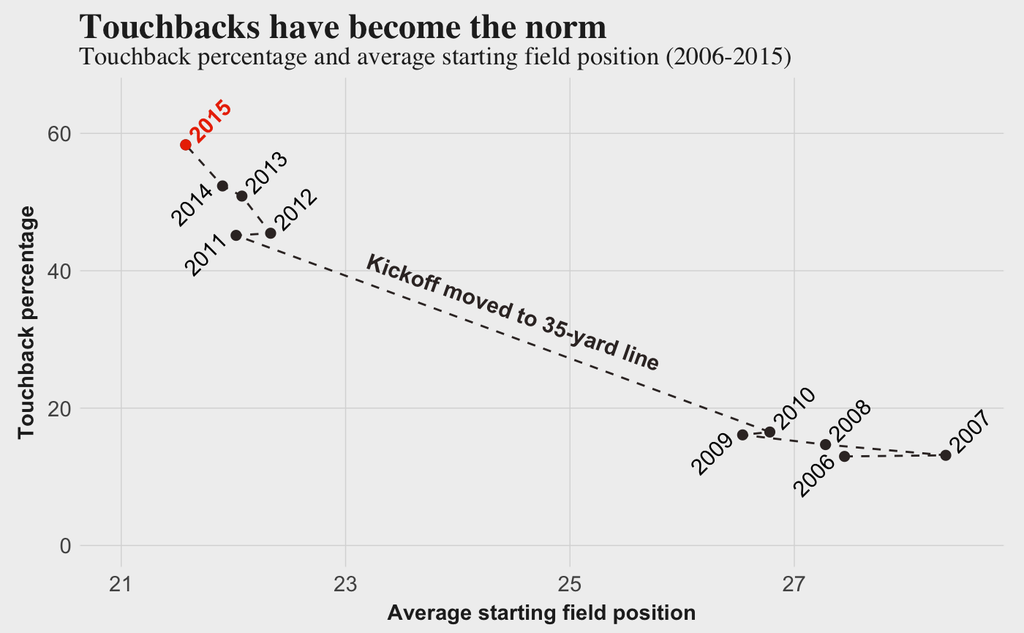

```r
ko <- ko %>% filter(fieldposition %in% c(-30,-35),
                    !is.na(kickresult),
                    !is.na(kickyards),
                    !kickresult %in% c('ONSIDE', 'FAIR CATCH', 'RECOVERED BY KICKING TEAM')) %>%
    mutate(touchback = ifelse(kickresult == 'TOUCHBACK', 1, 0),
           yfog = ifelse(touchback == 1, 20,
                         100 - (-fieldposition + kickyards - returnyards))) %>%
    filter(yfog > 0, yfog <= 100)
#Calculate the year-by-year average touchback percentage and starting field position
touchback_fp <- ko %>%
    group_by(gameseason) %>%
    summarise(touchback_per = mean(touchback)*100,
              avg_field_pos = mean(yfog))
#Separate years into different groups for arranging labels on the visualization
tb_2012_2009 <- filter(touchback_fp, gameseason %in% c(2006, 2009, 2011, 2014))
tb_other <- filter(touchback_fp, !gameseason %in% c(2006, 2009, 2011, 2014, 2015))
tb_2015 <- filter(touchback_fp, gameseason == 2015)
#Plot averge starting field position vs touchback percentage
ggplot(touchback_fp[order(touchback_fp$gameseason),], aes(avg_field_pos, touchback_per, label = gameseason)) +
    geom_point(size = 2, color = browns) +
    geom_path(linetype = 2, color = browns) +
    geom_point(data = tb_2015, size = 2, color = browns2) +
    geom_text(data = tb_other, hjust=-0.2, angle = 45, size = 4) +
    geom_text(data = tb_2015, hjust=-0.2, angle = 45, size = 4, color = browns2, fontface =2) +
    geom_text(data = tb_2012_2009, hjust=1.2, vjust = -0.05, angle = 45, size = 4) +
    coord_cartesian(ylim=c(0, 65), xlim=c(21, 28.5)) +
    labs(title='Touchbacks have become the norm', subtitle='Touchback percentage and average starting field position (2006-2015)', x='Average starting field position', y='Touchback percentage') +
    annotate("text", x = 24.5, y = 34, label = "Kickoff moved to 35-yard line", color = browns, fontface =2, angle = -19.55, size = 4) +
    fte_theme()
```

## Building Expected Points Added Calculations

### Field Goals

First, need to run LOESS regression on the kicks to get the expected field goal percentage. Using 2012-2015 data for larger sample sizes at each kick, plus smoothing out the years makes more sense than using only 2015, which had a extraordinarily high field-goal percentage above 50 yards, but lower than recent years in the 40s.

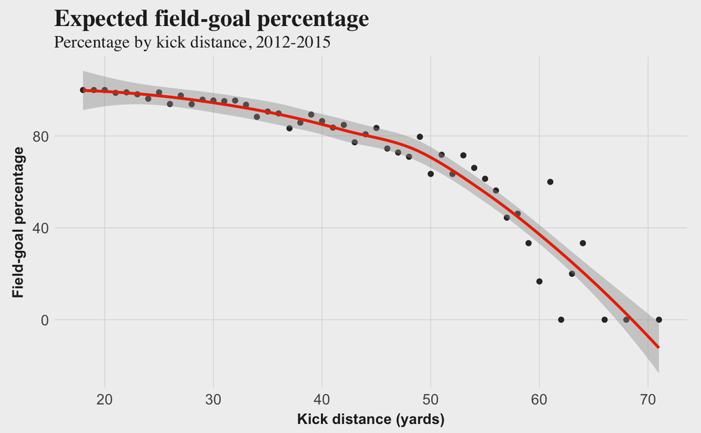

```r
#Calculate mean field-goal percentage by year
exp_fg_per <- filter(fg, gameseason >= 2012, gameseason <= 2015, kickyards >= 18) %>%
    group_by(kickyards) %>%
    summarise(fg_per = mean(made)*100)
#Graph kick distance vs expected field-goal percentage
ggplot(exp_fg_per, aes(kickyards, fg_per)) +
    geom_point(color = browns) +
    geom_smooth(color = browns2) +
    labs(title='Expected field-goal percentage', subtitle='Percentage by kick distance, 2012-2015', x='Kick distance (yards)', y='Field-goal percentage') +
    fte_theme()
```

```r
#Create a LOESS model to use for expected field-goal percentage in expected points calculations
exp_fg_per_model <- loess(fg_per ~ kickyards, data=exp_fg_per)
```

Get expected points data for assessing the point impact for made/missed field goals and kickoffs. Data from Armchair Analysis data. Load in data.

```r
aa_drive <- read_csv('~/Desktop/AA/nfl_00-16/DRIVE.csv')
aa_game <- read_csv('~/Desktop/AA/nfl_00-16/GAME.csv')
score <- read_csv('~/Desktop/AA/nfl_00-16/PLAY.csv') %>% select(pid, ptso, ptsd) %>%
    mutate(score_diff = ptso - ptsd)
setnames(score, 'pid', 'fpid')
```

Only use 2012-2015 data, first/third quarters and score within 10 points for “neutral” conditions. Based on only drive data, not all first-and-10 situations.

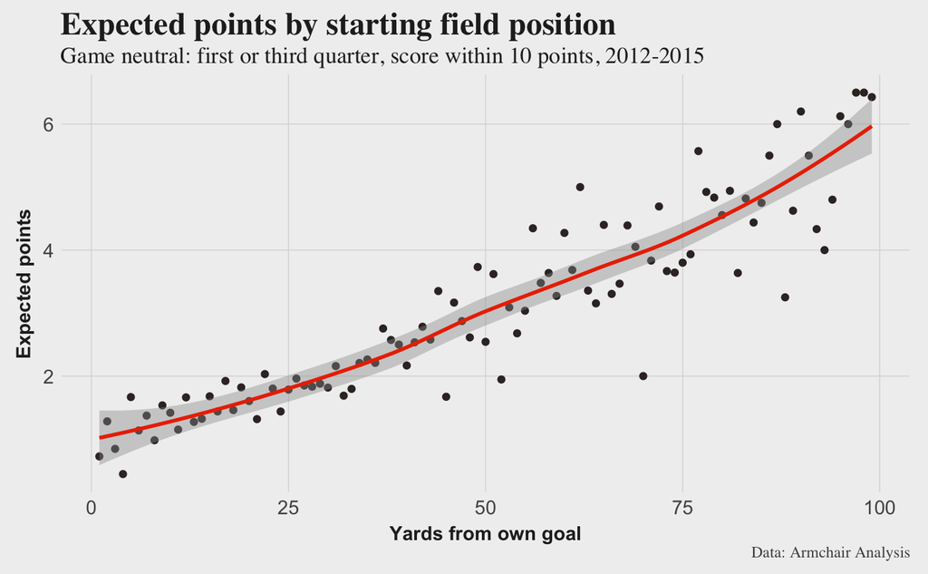

```r
#Calculate the points scored on drives by starting field position.
drives <- left_join(aa_drive, aa_game, by='gid') %>% left_join(score, by= 'fpid') %>%
    filter(seas >= 2012, seas <= 2015, qtr %in% c(1,3), score_diff < 10, score_diff > -10) %>%
    mutate(points = ifelse(res == 'TD', 7, ifelse(res == 'FG', 3, 0))) %>% select(yfog, points) %>%
    group_by(yfog) %>%
    summarise(ep = mean(points))
#Plot yards from own goal vs expected points
ggplot(drives, aes(yfog, ep)) +
    geom_point(color=browns) +
    geom_smooth(color=browns2) +
    labs(title='Expected points by starting field position', subtitle = 'Game neutral: first or third quarter, score within 10 points, 2012-2015', x='Yards from own goal', y='Expected points', caption = "Data: Armchair Analysis") +
    fte_theme()
```

Calculate the LOESS model for expected points for make and miss (need different names for later expected point calculations).

```r
#Make two LOESS models based on expecte points and drives
setnames(drives, 'yfog', 'yfog_made')
ep_model_make <- loess(ep ~ yfog_made, data=drives)
setnames(drives, 'yfog_made', 'yfog_miss')
ep_model_miss <- loess(ep ~ yfog_miss, data=drives)
```

Three components for field-goal expected points: 1) Actual field goal points, 2) Minus field-goal points expected, 3) Differential in opponents starting field position versus the opposite results (make/miss).

### Adjusting FG Percentage for Conditions

After much trial and error, found it was best to divide by three categories: dome, temperature over 40, and temperature under 40. Wind doesn’t look significant, as the direction is more important that the pure strength.

```r
fg_2012_2015 <- filter(fg, gameseason >=2012)
fg_2012_2015 <- mutate(fg_2012_2015, temp = ifelse(is.na(Temperature), 'Dome',
                                                   ifelse(Temperature >= 40, '40° or higher', 'Below 40°')))
group_by(fg_2012_2015, temp) %>% summarise(kicks = n())
```

| temp | kicks |
| --- | --- |
| 40° or higher | 3196 |
| Below 40° | 399 |
| Dome | 436 |

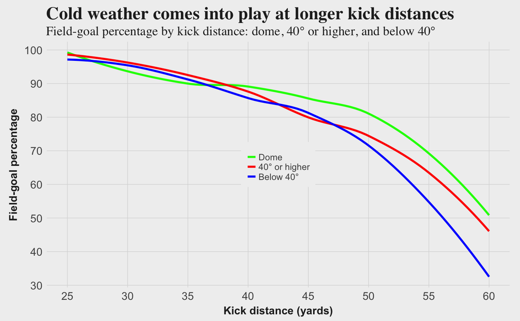

```r
fg_temp <- group_by(fg_2012_2015, dist, temp) %>%
    summarise(per = mean(made))
# Change factor levels for best display in graph
fg_temp$temp <- factor(fg_temp$temp, levels = c('Dome', '40° or higher', 'Below 40°'))
ggplot(fg_temp, aes(dist, per*100)) +
    geom_smooth(aes(color=temp), se = FALSE) + fte_theme() +
    scale_y_continuous(breaks= seq(30, 100, 10)) +
    scale_x_continuous(breaks= seq(20, 60, 5)) +
    labs(title='Cold weather comes into play at longer kick distances', subtitle='Field-goal percentage by kick distance: dome, 40° or higher, and below 40°', x='Kick distance (yards)', y='Field-goal percentage') +
    theme(legend.title=element_blank()) +
    theme(legend.position = c(0.50, 0.50)) +
    theme(legend.text = element_text(size=9)) +
    scale_color_manual(values=c("green", "red", "blue"))
```

Average is almost identical to ‘Warm’ Dome is 3%, 5%, 6%, and 7% higher at 45, 50, 55, 60 Cold is 1%, 4%, 8%, and 10% lower at 45, 50, 55, 60

```r
#Expected field goal percentage for each kick
fg_2012_2015$exp_fg <- predict(exp_fg_per_model, newdata = fg_2012_2015)/100
# Adjustments for weather
fg_2012_2015 <- mutate(fg_2012_2015,
                       exp_fg = ifelse(temp == 'Dome',
                                       ifelse(is.na(dist), exp_fg + 0.07,
                                       ifelse(dist == 45, exp_fg + 0.03,
                                       ifelse(dist == 50, exp_fg + 0.05,
                                       ifelse(dist == 55, exp_fg + 0.06,
                                       ifelse(dist == 60, exp_fg + 0.07, exp_fg))))),
                                ifelse(temp == 'Below 40°',
                                       ifelse(is.na(dist), exp_fg - 0.10,
                                       ifelse(dist == 45, exp_fg - 0.01,
                                       ifelse(dist == 50, exp_fg - 0.04,
                                       ifelse(dist == 55, exp_fg - 0.08,
                                       ifelse(dist == 60, exp_fg - 0.10, exp_fg))))),
                                exp_fg)),
                       made_adj = ifelse(temp == 'Dome',
                                       ifelse(is.na(dist), made - 0.07,
                                       ifelse(dist == 45, made - 0.03,
                                       ifelse(dist == 50, made - 0.05,
                                       ifelse(dist == 55, made - 0.06,
                                       ifelse(dist == 60, made - 0.07, made))))),
                                ifelse(temp == 'Below 40°',
                                       ifelse(is.na(dist), made + 0.10,
                                       ifelse(dist == 45, made + 0.01,
                                       ifelse(dist == 50, made + 0.04,
                                       ifelse(dist == 55, made + 0.08,
                                       ifelse(dist == 60, made + 0.10, made))))),
                                made)))
#Expected points for miss, which for kick of 30 or under is the 20, for higher it's kick distance minus 10 yards
fg_2012_2015 <- mutate(fg_2012_2015, yfog_miss = ifelse(kickyards < 30, 20, kickyards - 10),
                       yfog_made = 21.6)
#Points over expectation on the kick
fg_2012_2015$ep_made <- 3 - predict(ep_model_make, newdata=fg_2012_2015)
fg_2012_2015$ep_miss <- 0 - predict(ep_model_miss, newdata=fg_2012_2015)
#Expected points based on league averages
fg_2012_2015 <- mutate(fg_2012_2015, exp_ep = exp_fg * ep_made + (1 - exp_fg) * ep_miss,
                       epa = ifelse(made == 1, ep_made - exp_ep,
                           ep_miss - exp_ep))
```

Groupby ‘kickername’ to get kicking ep for all the kickers. Calculate Travis Coons’s numbers.

```r
fg_epa <- filter(fg_2012_2015, kickyards < 60, gameseason == 2015) %>%
    group_by(kickername) %>%
    summarise(kicks = n(), made = sum(made), percentage = round(made/kicks*100, 1), total_epa = round(sum(epa), 1),
              avg_epa = round(mean(epa), 3)) %>%
    filter(kicks >= 20)
filter(fg_epa, kickername == 'Coons, Travis')
```

| kickername | kicks | made | percentage | total_epa | avg_epa |
| --- | --- | --- | --- | --- | --- |
| Coons, Travis | 32 | 28 | 87.5 | -2 | -0.062 |

```r
head(arrange(fg_epa, desc(total_epa)), n=5)
```

| kickername | kicks | made | percentage | total_epa | avg_epa |
| --- | --- | --- | --- | --- | --- |
| Gostkowski, Stephen | 36 | 33 | 91.7 | 10.9 | 0.304 |
| Prater, Matt | 24 | 22 | 91.7 | 10.2 | 0.426 |
| Vinatieri, Adam | 29 | 27 | 93.1 | 10.1 | 0.347 |
| Hauschka, Steven | 31 | 29 | 93.5 | 9.8 | 0.317 |
| Brown, Josh | 33 | 31 | 93.9 | 9.1 | 0.275 |

```r
filter(fg_2012_2015, gameseason >=2012) %>% summarise(fg_per = mean(made))
```

| fg_per |
| --- |
| 0.8474324 |

League average FG percentage. Coons is higher than league average in percentage, but lower in EPA. We’ll explore why more later.

### Extra Points

Big drop in 2015 as the extra point was moved back to the 15-yard line.

```r
xp %>% filter(!is.na(kickresult), gameseason >= 2015) %>%
    mutate(made = ifelse(grepl("MADE", kickresult), 1, 0)) %>%
    summarise(avg_per = mean(made))
```

| avg_per |
| --- |
| 0.9401639 |

2015 kickers versus average and calculate expected points added

```r
#Using the league-average XP percentage to find expected points added for each kicker in 2015
xp_epa <- xp %>% filter(gameseason == 2015) %>%
    mutate(exp = 0.9401639, epa = made - exp) %>%
    group_by(kickername) %>%
    summarise(kicks = n(), made = sum(made), percentage = round(made/kicks*100, 1), total_epa = round(sum(epa), 1),
              avg_epa = round(mean(epa), 3)) %>%
    filter(kicks >= 20)
filter(xp_epa, kickername == 'Coons, Travis')
```

| kickername | kicks | made | percentage | total_epa | avg_epa |
| --- | --- | --- | --- | --- | --- |
| Coons, Travis | 24 | 22 | 91.7 | -0.6 | -0.023 |

```r
head(arrange(xp_epa, desc(total_epa)), n=5)
```

| kickername | kicks | made | percentage | total_epa | avg_epa |
| --- | --- | --- | --- | --- | --- |
| Gostkowski, Stephen | 52 | 52 | 100.0 | 3.1 | 0.060 |
| Crosby, Mason | 36 | 36 | 100.0 | 2.2 | 0.060 |
| Nugent, Mike | 50 | 49 | 98.0 | 2.0 | 0.040 |
| Brown, Josh | 45 | 44 | 97.8 | 1.7 | 0.038 |
| Tucker, Justin | 29 | 29 | 100.0 | 1.7 | 0.060 |

### Kickoffs

Get the average yardline after kickoffs (2015) for calculating the expected points after a made FG or kickoffs.

```r
ko_avg_yfog <- filter(ko, gameseason == 2015) %>%
    summarise(avg_yfog = mean(yfog))
ko_avg_yfog
```

| avg_yfog |
| --- |
| 21.57443 |

```r
# How many touchdowns and total kicks for adding to EPA totals
nrow(filter(ko, gameseason == 2015, yfog == 100))
```

```
[1] 6
```

Calculate kickoff expected points added based on the numbers calculated earlier

```r
avg_ko <- 21.57443
#Create a couple columns to use with the LOESS regression for expected points at starting field position
ko_epa <- ko %>%
    filter(gameseason == 2015) %>%
    mutate(yfog_made = avg_ko, yfog_miss = yfog)
#Add expected points for kickoffs
ko_epa$exp_ep <- predict(ep_model_make, newdata = ko_epa) + (6*7)/nrow(ko_epa) #Includes touchdowns (6)
#Add -7 for 100 yfog, which should be a return touchdown. If not 100, use the regression
ko_epa$ep <- ifelse(ko_epa$yfog_miss == 100, 7, predict(ep_model_miss, newdata = ko_epa))
#Difference is the expected points added
ko_epa$epa <- ko_epa$exp_ep - ko_epa$ep
#Now group by kicker for EPA numbers and touchback percentages
ko_epa <- ko_epa %>%
    group_by(kickername) %>%
    summarise(kicks = n(), touchbacks = sum(touchback),
              percentage = round(touchbacks/kicks*100, 1),
              total_epa = round(sum(epa), 1),
              avg_epa = round(mean(epa), 3)) %>%
  filter(kicks >= 20)
#View Coons
coons <- filter(ko_epa, kickername == 'Coons, Travis')
coons
```

| kickername | kicks | touchbacks | percentage | total_epa | avg_epa |
| --- | --- | --- | --- | --- | --- |
| Coons, Travis | 68 | 26 | 38.2 | 0.7 | 0.011 |

```r
head(arrange(ko_epa, desc(total_epa)), n=30)
```

| kickername | kicks | touchbacks | percentage | total_epa | avg_epa |
| --- | --- | --- | --- | --- | --- |
| Gostkowski, Stephen | 94 | 66 | 70.2 | 6.3 | 0.067 |
| Gay, Jordan | 73 | 41 | 56.2 | 6.1 | 0.083 |
| McAfee, Pat | 71 | 64 | 90.1 | 5.2 | 0.074 |
| Nugent, Mike | 87 | 41 | 47.1 | 4.5 | 0.051 |
| Tucker, Justin | 71 | 62 | 87.3 | 4.4 | 0.062 |
| Bailey, Dan | 70 | 49 | 70.0 | 3.6 | 0.051 |
| McManus, Brandon | 75 | 53 | 70.7 | 3.1 | 0.042 |
| Santos, Cairo | 82 | 39 | 47.6 | 3.0 | 0.036 |
| Hopkins, Dustin | 76 | 52 | 68.4 | 2.8 | 0.037 |
| Bullock, Randy | 53 | 29 | 54.7 | 2.5 | 0.046 |

[output cut: 20 more lines]

View top kickers by total EPA on kickoffs

```r
ko %>% filter(gameseason == 2015) %>% summarise(avg_tb_per = mean(touchback))
```

| avg_tb_per |
| --- |
| 0.5833333 |

Average touchback percentage in 2015 was 58.3% versus Coons at only 38.2%.

### Combine Field Goals, Extra Points & Kickoffs

Join all the data together for FG, XP and KO EPA for a visualization to compare all 2015 kickers

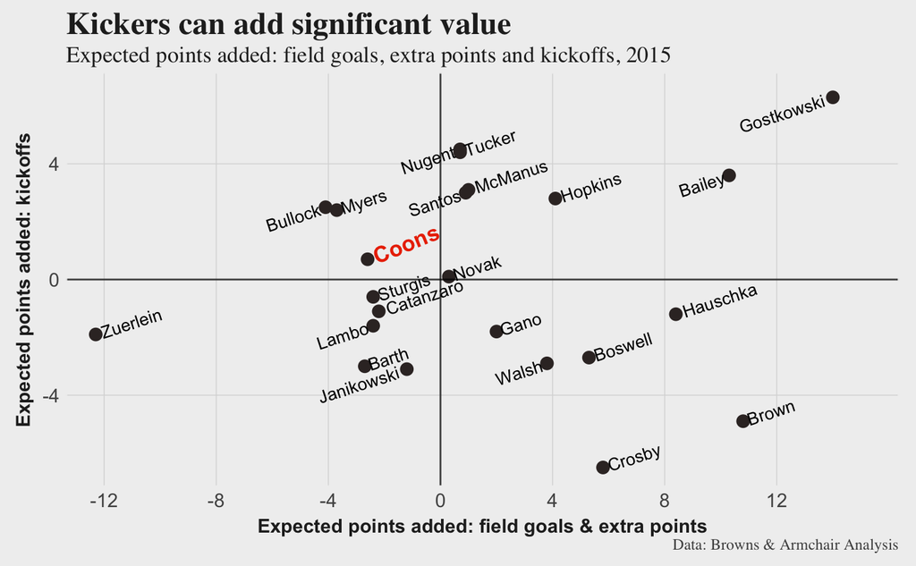

```r
fg_ko <- fg_epa %>%
    inner_join(ko_epa, by='kickername') %>%
    inner_join(xp_epa, by='kickername') %>%
    mutate(total_kicks = kicks.x + kicks.y, total_epa.x = total_epa.x + total_epa)
#Get rid on first names to fit better in the viz
fg_ko$name <- str_split_fixed(fg_ko$kickername, ', ', 2)[,1]
#Split some kickers off for later changing the orientation on graph labels
fg_ko_1 <- fg_ko %>%
    filter(!name %in% c('Walsh', 'Coons','Bullock', 'Nugent', 'Gostkowski', 'Bailey',
                        'Janikowski', 'Lambo', 'Santos'))
fg_ko_2 <- fg_ko %>%
    filter(name %in% c('Walsh', 'Bullock', 'Nugent', 'Gostkowski', 'Bailey',
                       'Janikowski', 'Lambo', 'Santos'))
#Separate Coons for different color label in graph
coons <- filter(fg_ko, name == 'Coons')
ggplot(fg_ko, aes(total_epa.x, total_epa.y)) +
    geom_point(color = browns, size = 3) +
    geom_vline(xintercept = 0, alpha = 0.7) +
    geom_hline(yintercept = 0, alpha = 0.7) +
    labs(title='Kickers can add significant value', subtitle='Expected points added: field goals, extra points and kickoffs, 2015', y='Expected points added: kickoffs', x='Expected points added: field goals & extra points', size = "FG Att & KO", caption = "Data: Browns & Armchair Analysis") +
    geom_text(data = fg_ko_1, aes(label=name), hjust=-0.1, size = 3.5, angle = 18) +
    geom_text(data = fg_ko_2, aes(label=name), hjust= 1.1, size = 3.5, angle = 18) +
    geom_text(data = coons, aes(label=name), hjust= -0.1, size = 4.5, angle = 22, color = browns2, fontface =2) +
    coord_cartesian(xlim=c(-12, 15), ylim=c(-6.5, 6.5)) +
    fte_theme() +
    theme(legend.position = c(0.12, 0.75)) +
    scale_x_continuous(breaks=seq(-12, 14, 4))
```

Graph show kickoff EPA versus that for FG/XPs for all 2015 kickers with 20+ FG attempts. Coons falls into the negative FG/positive KO bucket. Coons was likely lucky to have positive KO EPA considering his low touchback percentage.

## Exploring High FG Percentage & Low EPA

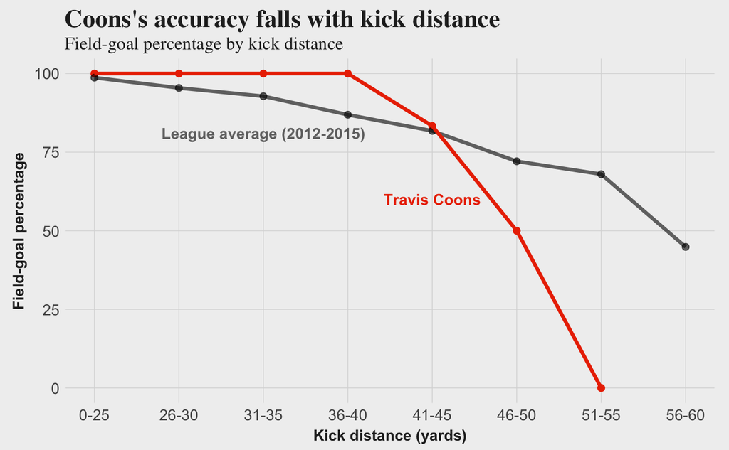

```r
coons <- filter(fg, kickername == 'Coons, Travis') %>%
    group_by(dist) %>%
    summarise(fg_per = mean(made)*100, kicks = n())
fg_12_15 <- filter(fg_year, gameseason >= 2012, gameseason <= 2015) %>%
    group_by(dist) %>%
    summarise(fg_per = mean(fg_per))
ggplot(fg_12_15, aes(dist, fg_per)) +
    geom_point(data=coons, color=browns2, size = 2) +
    geom_point(size = 2, alpha = 0.6) +
    geom_line(size = 1.25, alpha = 0.6) +
    geom_line(data=coons, color = browns2, size = 1.25) +
    labs(title="Coons's accuracy falls with kick distance", subtitle='Field-goal percentage by kick distance', x='Kick distance (yards)', y='Field-goal percentage') +
    coord_cartesian(ylim=c(0, 100)) +
    annotate("text", x = 45, y = 60, label = "Travis Coons", color = browns2, fontface =2) +
    annotate("text", x = 35, y = 81, label = "League average (2012-2015)", color = 'black', alpha = 0.6, fontface =2) +
    scale_x_continuous(breaks=seq(25,60,5), labels=c('0-25','26-30','31-35','36-40','41-45','46-50','51-55','56-60'), minor_breaks = NULL) +
    fte_theme()
```

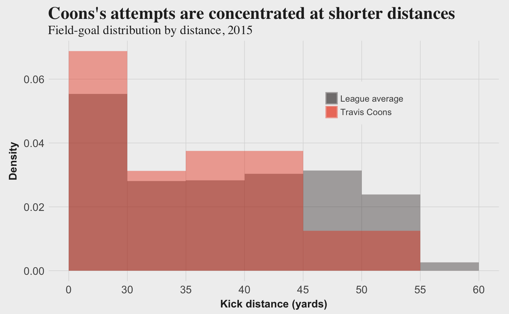

```r
hist_2015 <- filter(fg, gameseason == 2015)
coons <- filter(fg, kickername == 'Coons, Travis')
ggplot() +
geom_histogram(data=hist_2015, aes(dist, ..density.., fill = browns), alpha = 0.4, breaks=seq(25,60,5), size =3) +
    geom_histogram(data=coons, aes(dist, ..density.., fill = browns2), alpha = 0.4, breaks=seq(25,60,5)) +
    scale_x_continuous(breaks=seq(25,60,5), labels=c(0,30,35,40,45,50,55,60), minor_breaks = NULL) +
    labs(title="Coons's attempts are concentrated at shorter distances", subtitle='Field-goal distribution by distance, 2015', x='Kick distance (yards)', y='Density') +
    scale_fill_identity(name = NULL, guide = 'legend',labels = c('League average', 'Travis Coons')) +
    guides(colour = guide_legend(override.aes = list(alpha = 0.5))) +
    fte_theme() +
    theme(legend.position = c(0.7, 0.74)) +
    theme(legend.key.size = unit(0.5, "cm")) +
    theme(legend.text = element_text(size=9))
```

Coons’s distribution is much more concentrated to shorter distances than the league average in 2015.

## Bayesian Analysis for Forecasting

### Calculating Adjusted FG Percentage

What should we expect from Travis Coons going forward? In order to use Bayesian inference with the beta distribution, but need to normalize all kickers to have the same distribution of kicks to compare FG percentages.

Adjusted field-goal percentage normalizes every kicker’s kick distance distribution to the 2015 league-wide distribution. This adjusted results for kick difficultly and gives us a better number for comparision and projection.

Calculating adjusted FG percentage

```r
#Calculating the league-wide kick distribution in 2015
league_freq <- filter(fg_2012_2015, gameseason == 2015) %>%
    group_by(dist) %>%
    filter(!is.na(dist)) %>%
    summarise(kicks = n()) %>%
    mutate(freq = kicks/sum(kicks)) %>%
    select(dist, freq)
#Using the 2012-2015 kicker cohort to find the individual kickers for the prior distribution
kickers <- unique(filter(fg, gameseason >= 2012, kickername != 'NULL')$kickername)
adj_fg <- data_frame()
#Loop through the list of kickers from 2012-2015 to calculate the adjusted FG percentage
for (i in 1:length(kickers)){
    kicker = filter(fg_2012_2015, kickername == kickers[i]) %>%
        group_by(kickername, dist) %>%
        summarise(kicks = n(),
                  made = sum(made_adj)) %>%
        filter(sum(kicks) >= 20) %>% #Minimum of 30 kicks to eliminate kickers without much history
        left_join(league_freq, by = 'dist') %>%
        mutate(fg_per = made/kicks,
               adj_fg = freq*fg_per) %>%
        filter(!is.na(adj_fg)) %>%
        group_by(kickername) %>%
        summarise(adj_fg = sum(adj_fg))

    adj_fg <- rbind(adj_fg, kicker)
}
arrange(adj_fg, adj_fg)
```

| kickername | adj_fg |
| --- | --- |
| Akers, David | 0.6487331 |
| Murray, Patrick | 0.7434237 |
| Forbath, Kai | 0.7606413 |
| Coons, Travis | 0.7681627 |
| Cundiff, Billy | 0.7805748 |
| Hartley, Garrett | 0.7811335 |
| Tynes, Lawrence | 0.7877069 |
| Sturgis, Caleb | 0.7881302 |
| McManus, Brandon | 0.7900368 |
| Bironas, Rob | 0.8001962 |

[output cut: 36 more lines]

### Beta Distribution for Adjust FG Percentage

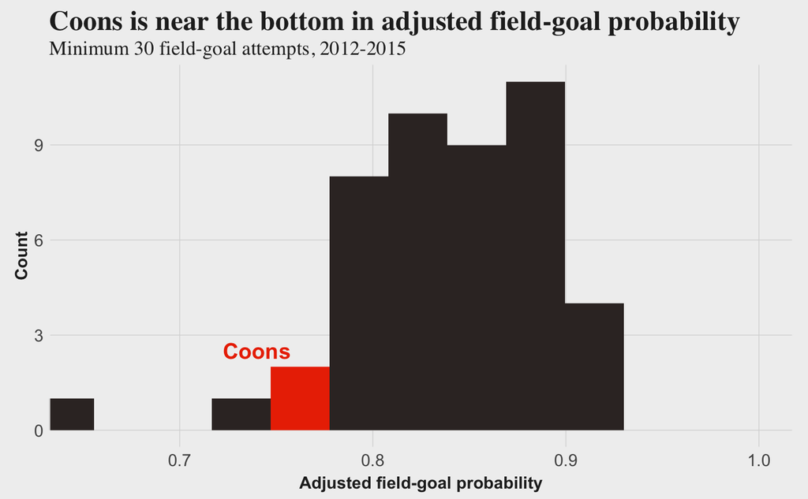

```r
#Manually select colors to highlight Coons in blue
colors <- c(rep(browns,4), rep(browns2,1), rep(browns,5))
#Plot probability distribution
ggplot(adj_fg, aes(adj_fg)) +
    geom_histogram(bins=10, fill = colors) +
    labs(title='Coons is near the bottom in adjusted field-goal probability', subtitle='Minimum 30 field-goal attempts, 2012-2015', x='Adjusted field-goal probability', y='Count') +
    fte_theme() + coord_cartesian(xlim=c(0.65,1)) +
    annotate("text", x = 0.74, y = 2.5, label = "Coons", color = browns2, fontface =2, size = 5)
```

The distribution of kickers’ adjusted FG percentages with Coons highlighted in orange. We now build the beta distribution that best fits the actual distribution. Beta distributions can be easily updated with Coons’s adjusted field goal results to form a posterior distribution we can use to project Coons moving forward. We use the “beta.select” function from the TeachBayes package for finding the prior and posterior.

[figure not shown]

```r
# Specify the 0.20 quantile
quantile1 <- list(p = 0.20, x = 0.80)
# Specify the 0.80 quantile
quantile2 <- list(p = 0.80, x = 0.875)
# Find the beta shape parameters matching the two quantiles: ab
ab <- beta.select(quantile1, quantile2)
# Plot the beta curve using the beta_draw() function
beta_draw(ab) + fte_theme() +
    scale_colour_manual(browns) +
    labs(title="Prior beta distribution (49.49, 8.86)", subtitle='Kick distribution adjusted to league average, 2012-2015', x='Adjusted field-goal probability')
```

#### Posterior Beta Distribution

Now that we have the prior, let’s apply Coons’s adjusted results. The adjusted results are based on same number of kicks (32), but the makes and misses determined by Coons’s adjusted FG percentage.

[output not shown]

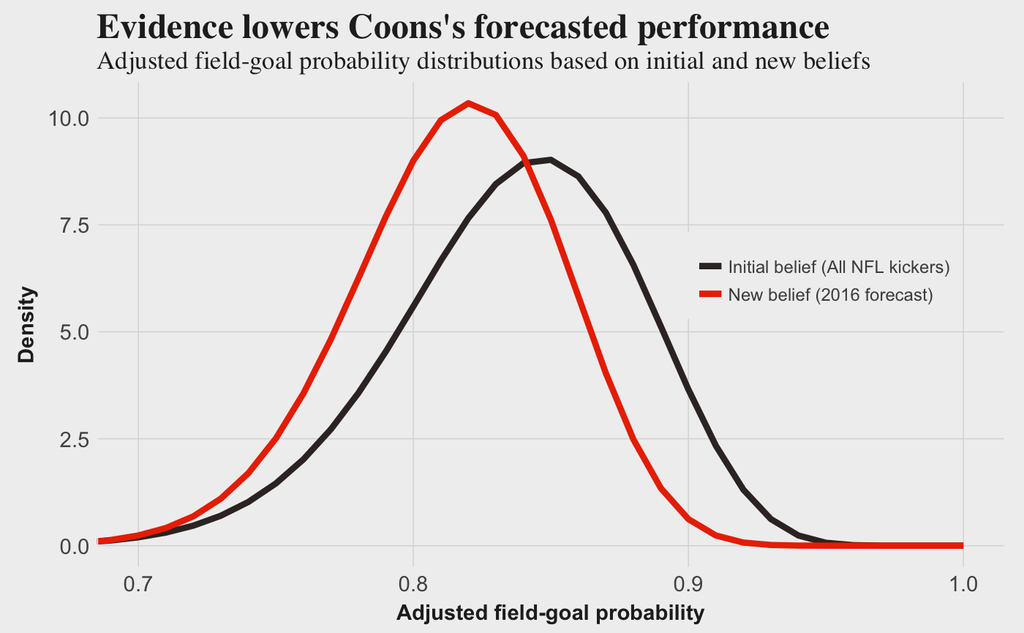

```r
#Get Coons's makes and misses based on the adjuste FG percentage calculation
makes <- filter(adj_fg, kickername == 'Coons, Travis')$adj_fg * 32
misses <- 32 - makes
post_ab = ab + c(makes, misses)
#Graph the posterior and prior
beta_prior_post(ab, post_ab, label_1="Initial belief (All NFL kickers)", label_2="New belief (2016 forecast)") +
    scale_colour_manual(values = c(browns, browns2)) +
    fte_theme() +
    coord_cartesian(xlim=c(0.7,1)) +
    theme(legend.position = c(0.8, 0.6)) +
    theme(legend.title=element_blank()) +
    theme(legend.key.size = unit(0.5, "cm")) +
    theme(legend.text = element_text(size=9)) +
    labs(title="Evidence lowers Coons's forecasted performance", subtitle="Adjusted field-goal probability distributions based on initial and new beliefs", x='Adjusted field-goal probability') +
    coord_cartesian(xlim=c(0.7, 1))
```

#### Credible Intervals

```r
#All NFL kickers 10th and 90th percentile
qbeta(c(0.1, 0.9), ab[1], ab[2])
```

```
[1] 0.7774114 0.8913571
```

```r
#Coons's forecast 10th and 90th percentile
qbeta(c(0.1, 0.9), post_ab[1], post_ab[2])
```

```
[1] 0.7637043 0.8628274
```

```r
#All NFL kickers best guess
ab[1] / (ab[1] + ab[2])
```

```
[1] 0.8365512
```

```r
#Travis Coons best guess
post_ab[1] / (post_ab[1] + post_ab[2])
```

```
[1] 0.814634
```

```r
makes/(makes + misses)
```

```
[1] 0.7681627
```

Calculate the credible intervals for the prior and posterior, then find the middle of both distributions.

#### Expected Points

Now we need to take the posterior numbers and apply it to the expected points framework.

```r
#Add the expected point averages for the different frequencies
adj_epa <- function(adj_per, kicks){
    adj_epa <- fg_2012_2015 %>%
    select(dist, ep_made, ep_miss, exp_ep) %>%
    mutate(epa = (adj_per*ep_made + (1-adj_per)*ep_miss) - exp_ep) %>%
    summarise(mean(epa)*kicks)

    return(adj_epa[1,1][[1]])
}
#Best guess EPA for Coons
adj_epa(0.814634, mean(fg_epa$kicks))
```

```
[1] -1.858039
```

```r
#Bottom of 90% credible interval EPA
adj_epa(0.7637043, mean(fg_epa$kicks))
```

```
[1] -7.05574
```

```r
#Top of 90% credible interval EPA
adj_epa(0.8628274, mean(fg_epa$kicks))
```

```
[1] 3.060406
```

```r
#Best guess EPA
adj_epa(0.8365512, mean(fg_epa$kicks))
```

```
[1] 0.3787514
```

```r
#Bottom of 90% credible interval EPA
adj_epa(0.7774114, mean(fg_epa$kicks))
```

```
[1] -5.656843
```

```r
#Top of 90% credible interval EPA
adj_epa(0.8913571, mean(fg_epa$kicks))
```

```
[1] 5.972044
```

### Beta Distribution Extra Points

Calculate extra points distribution based on on 2015.

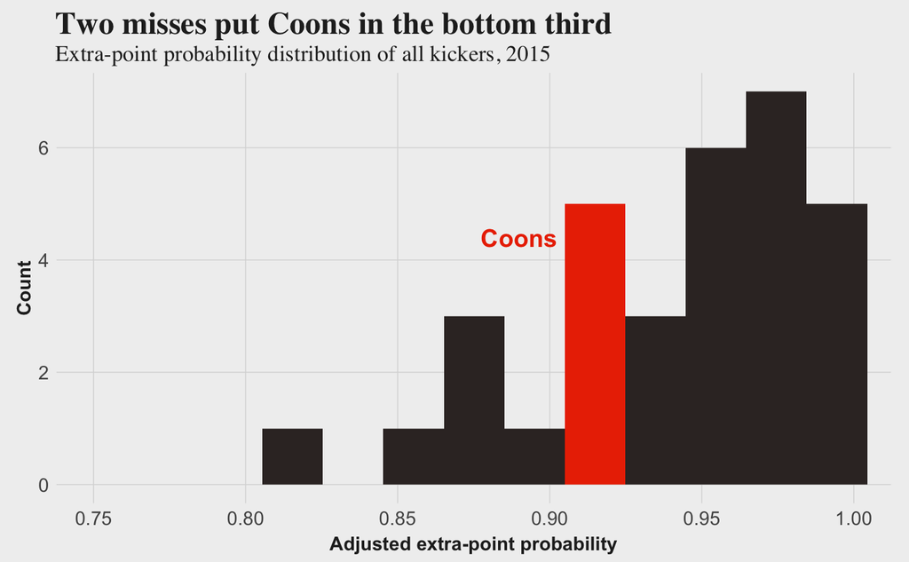

```r
#Manually select colors to highlight Coons in blue
colors <- c(rep(browns,5), rep(browns2,1), rep(browns,4))
#Plot probability distribution
ggplot(xp_epa, aes(percentage/100)) +
    geom_histogram(bins=10, fill = colors) +
    labs(title='Two misses put Coons in the bottom third', subtitle='Extra-point probability distribution of all kickers, 2015', x='Adjusted extra-point probability', y='Count') +
    fte_theme() + coord_cartesian(xlim=c(0.75,1)) +
    annotate("text", x = 0.89, y = 4.4, label = "Coons", color = browns2, fontface =2, size = 5)
```

[figure not shown]

```r
# Specify the 0.20 quantile
quantile1 <- list(p = 0.29, x = 0.915)
# Specify the 0.80 quantile
quantile2 <- list(p = 0.87, x = .99)
# Find the beta shape parameters matching the two quantiles: ab
ab <- beta.select(quantile1, quantile2)
# Plot the beta curve using the beta_draw() function
beta_draw(ab) + fte_theme() +
    scale_colour_manual(browns) +
    labs(title="Prior beta distribution (49.49, 8.86)", subtitle='NFL kicker extra point distribution, 2012-2015', x='Adjusted field-goal probability')
```

#### Posterior Beta Distribution

[output not shown]

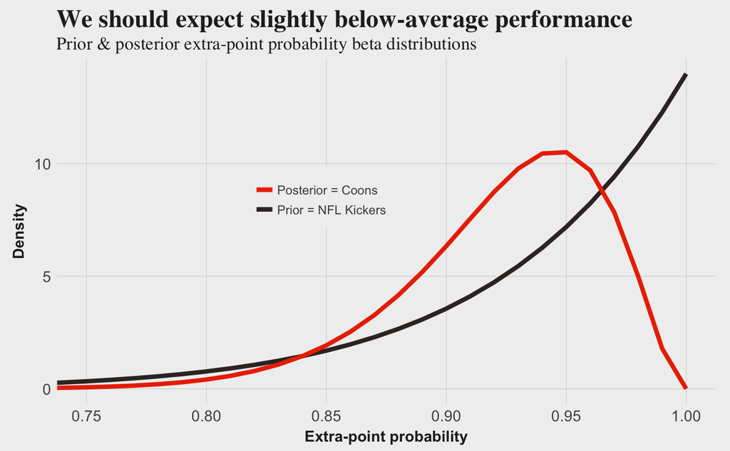

```r
#Get Coons's makes and misses based on the adjuste FG percentage calculation
post_ab = ab + c(22, 2)
#Graph the posterior and prior
beta_prior_post(ab, post_ab, label_1="Prior = NFL Kickers", label_2="Posterior = Coons") +
    scale_colour_manual(values = c(browns2, browns)) +
    fte_theme() +
    coord_cartesian(xlim=c(0.7,1)) +
    theme(legend.position = c(0.4, 0.6)) +
    theme(legend.title=element_blank()) +
    theme(legend.key.size = unit(0.5, "cm")) +
    theme(legend.text = element_text(size=9)) +
    labs(title="We should expect slightly below-average performance", subtitle='Prior & posterior extra-point probability beta distributions', x='Extra-point probability') +
    coord_cartesian(xlim=c(0.75,1))
```

#### Credible Intervals

```r
#All NFL kickers 10th and 90th percentile
qbeta(c(0.1, 0.9), ab[1], ab[2])
```

```
[1] 0.8482432 0.9924972
```

```r
#Coons's forecast 10th and 90th percentile
qbeta(c(0.1, 0.9), post_ab[1], post_ab[2])
```

```
[1] 0.8659162 0.9706369
```

```r
#All NFL kickers best guess
ab[1] / (ab[1] + ab[2])
```

```
[1] 0.9332889
```

```r
#Travis Coons best guess
post_ab[1] / (post_ab[1] + post_ab[2])
```

```
[1] 0.9230572
```

#### Expected Points

Calculate expected points added on extra points

```r
epa <- function(xp_per, kicks){
    epa <- (xp_per - 0.9401639)*kicks
    return(epa)
}
#Best guess EPA for Coons
epa(0.9230572, mean(xp_epa$kicks))
```

```
[1] -0.6153066
```

```r
#Bottom of 90% credible interval EPA
epa(0.8659162, mean(xp_epa$kicks))
```

```
[1] -2.670597
```

```r
#Top of 90% credible interval EPA
epa(0.9706369, mean(xp_epa$kicks))
```

```
[1] 1.096076
```

Entire NFL prior for extra point epa

```r
epa <- function(xp_per, kicks){
    epa <- (xp_per - 0.9401639)*kicks
    return(epa)
}
#Best guess EPA for Coons
epa(0.9332889, mean(xp_epa$kicks))
```

```
[1] -0.2472852
```

```r
#Bottom of 90% credible interval EPA
epa(0.8482432, mean(xp_epa$kicks))
```

```
[1] -3.306273
```

```r
#Top of 90% credible interval EPA
epa(0.9924972, mean(xp_epa$kicks))
```

```
[1] 1.882363
```

### Beta Distribution for Blocks

When you look through the data, you notice that all of Coons’s misses were labeled “MISSED - B”, which indicates the attempts were blocked. This seems extraordinary to have such a high block percentage.

```r
filter(fg, gameseason == 2015, !is.na(kickresult)) %>%
    mutate(block = ifelse(kickresult == 'MISSED - B', 1, 0)) %>%
    summarise(block_per = round((sum(block)/n())*100, 1))
```

| block_per |
| --- |
| 2.4 |

The block percentage for all 2015 kicks with 2.4%. Now calculate the block percentage for each kicker in 2015.

```r
block_kicker <- fg %>%
    filter(gameseason == 2015, !is.na(kickresult)) %>%
    mutate(block = ifelse(kickresult == 'MISSED - B', 1, 0)) %>%
    group_by(kickername) %>%
    summarise(kicks = n(),
              blocks = sum(block),
              block_percentage = round((blocks/kicks)*100, 1)) %>%
    mutate(blocks_over_expectation = round(blocks - 0.024*kicks, 1)) %>%
    filter(kickername != 'NULL', kicks >= 20)
filter(block_kicker, kickername == 'Coons, Travis')
```

| kickername | kicks | blocks | block_percentage | blocks_over_expectation |
| --- | --- | --- | --- | --- |
| Coons, Travis | 32 | 4 | 12.5 | 3.2 |

```r
head(arrange(block_kicker, desc(block_percentage)), n=5)
```

| kickername | kicks | blocks | block_percentage | blocks_over_expectation |
| --- | --- | --- | --- | --- |
| Coons, Travis | 32 | 4 | 12.5 | 3.2 |
| Zuerlein, Greg | 30 | 3 | 10.0 | 2.3 |
| Gano, Graham | 35 | 3 | 8.6 | 2.2 |
| Dawson, Phil | 27 | 2 | 7.4 | 1.4 |
| Janikowski, Sebastian | 26 | 1 | 3.8 | 0.4 |

Very few kickers had more than one block in 2015.

Using Armchair Analysis data again to investigate into block trends for the historical 2012-2015 period because the provided data doesn’t have the “MISSED - B” for many of the historical years.

```r
aa_fgxp <- read_csv('~/Desktop/AA/nfl_00-16/FGXP.csv')
aa_play <- read_csv('~/Desktop/AA/nfl_00-16/PLAY.csv')
```

Read in kicking info from Armchair Analysis

```r
#Get the historical block information by joining play, game and fgxp data
hist_blocks <- aa_play %>%
    left_join(aa_game, by = 'gid') %>%
    filter(seas >= 2012,
           seas <= 2015) %>%
    left_join(aa_fgxp, by = 'pid') %>%
    filter(!is.na(fkicker),
           fgxp == 'FG') %>%
    group_by(fkicker) %>%
    summarise(kicks = n(),
              blocks = sum(blk),
              block_per = (blocks/kicks)*100) %>%
    filter(kicks >= 30) #Limiting to those with at least 50 kicks
head(arrange(hist_blocks, desc(block_per)), n=5)
```

| fkicker | kicks | blocks | block_per |
| --- | --- | --- | --- |
| TC-2450 | 32 | 4 | 12.500000 |
| DA-0300 | 71 | 5 | 7.042254 |
| GG-0100 | 119 | 6 | 5.042017 |
| KF-0250 | 82 | 4 | 4.878049 |
| JS-1100 | 89 | 4 | 4.494382 |

Highest block percentages for 2012-2015 were only at 7% outside of Coons, whose block percentage was 12.5%.

Create histogram of block percentage for 2012-2015 for another updated beta distribution.

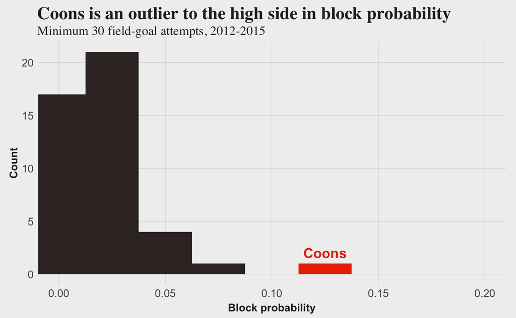

```r
#Manually select colors to highlight Coons in blue
colors <- c(rep(browns,5), rep(browns2,1))
ggplot(hist_blocks, aes(block_per/100)) +
    geom_histogram(bins=6, fill=colors) +
    labs(title='Coons is an outlier to the high side in block probability', subtitle='Minimum 30 field-goal attempts, 2012-2015', x='Block probability', y='Count') +
    fte_theme() + coord_cartesian(xlim=c(0,0.20)) +
    annotate("text", x = 0.125, y = 2, label = "Coons", color = browns2, fontface =2, size = 5)
```

Create prior with quantiles.

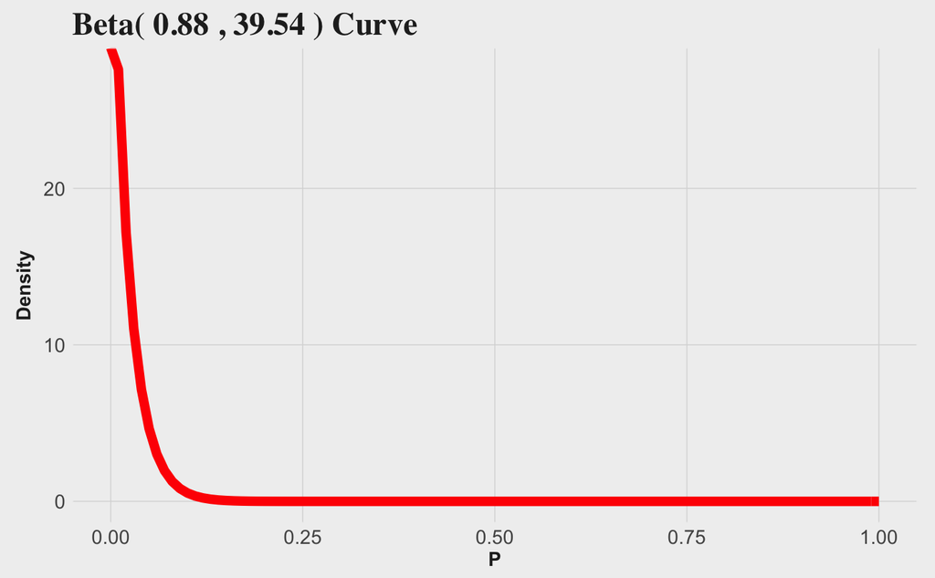

```r
# Specify that the 0.25 quantile of P is equal to 0.7: quantile1
quantile1 <- list(p = 0.30, x = 0.0070)
# Specify that the 0.75 quantile of P is equal to 0.85: quantile2
quantile2 <- list(p = 0.75, x = 0.030303030)
# Find the beta shape parameters matching the two quantiles: ab
ab <- beta.select(quantile1, quantile2)
# Plot the beta curve using the beta_draw() function
beta_draw(ab) + fte_theme()
```

#### Posterior Beta Distribution

Add Coons’s four blocks and 28 unblocked attempts.

[output not shown]

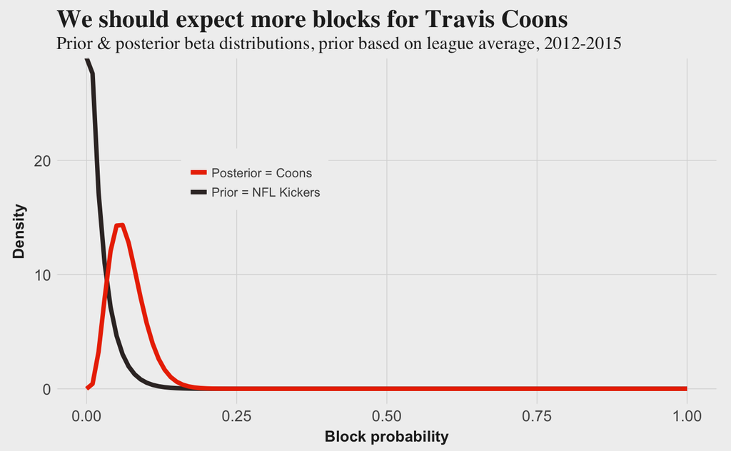

```r
# Plot the prior and  function
post_ab = ab + c(4,28)
beta_prior_post(ab, post_ab, label_1="Prior = NFL Kickers", label_2="Posterior = Coons") +
    scale_colour_manual(values = c('blue', 'red')) +
    fte_theme() +
    scale_colour_manual(values = c(browns2, browns)) +
    #coord_cartesian(xlim=c(0,0.20)) +
    theme(legend.position = c(0.3, 0.65)) +
    theme(legend.title=element_blank()) +
    theme(legend.key.size = unit(0.5, "cm")) +
    theme(legend.text = element_text(size=9)) +
    labs(title="We should expect more blocks for Travis Coons", subtitle='Prior & posterior beta distributions, prior based on league average, 2012-2015', x='Block probability')
```

#### Credible Intervals

```r
#All NFL kickers 10th and 90th percentile
qbeta(c(0.1, 0.9), ab[1], ab[2])
```

```
[1] 0.001822641 0.051581207
```

```r
#Coons's forecast 10th and 90th percentile
qbeta(c(0.1, 0.9), post_ab[1], post_ab[2])
```

```
[1] 0.03324093 0.10672456
```

```r
#All NFL kickers best guess
ab[1] / (ab[1] + ab[2])
```

```
[1] 0.0217714
```

```r
#Travis Coons best guess
post_ab[1] / (post_ab[1] + post_ab[2])
```

```
[1] 0.0673847
```

Best guess for Coons is much higher than prior for the league average: 6.7% versus 2.1%.

### Kickoff Rule Changes

```r
filter(ko, kickresult != 'TOUCHBACK',
       gameseason == 2015) %>%
    summarise(avg_fp = mean(yfog))
```

| avg_fp |
| --- |
| 23.77864 |

Average starting field position for non-touchbacks was between the 23- and 24-yard line. New touchback rules for 2016 (starting at the 25-yard line) will make touchbacks likely negative EPA events. This minimizes the downside to Travis Coons’s lower touchback percentage. Although, there could be a link between leg strength and the ability to put more air under the ball (forcing shorter returns), which would be a negative for Coons.

### Screening for Free Agent Kickers to Sign

Look at historical adjusted FG numbers to find potential replacements for Coons that weren’t on a roster at some point furing the 2016 offseason.

```r
arrange(adj_fg, desc(adj_fg))
```

| kickername | adj_fg |
| --- | --- |
| Bailey, Dan | 0.9231444 |
| Boswell, Chris | 0.9168440 |
| Brown, Josh | 0.9086132 |
| Hauschka, Steven | 0.9011957 |
| Tucker, Justin | 0.8920355 |
| Gostkowski, Stephen | 0.8894664 |
| Hopkins, Dustin | 0.8857229 |
| Dawson, Phil | 0.8851188 |
| Hanson, Jason | 0.8836212 |
| Vinatieri, Adam | 0.8757132 |

[output cut: 36 more lines]

Potential kickers to find in free agency based on strong past performance for Adjusted FG Percentage:

Patrick Murray (released May 19, 2016), Adjusted FG probability: 0.845*, 24 kicks* Had only one attempt (missed) from under 25 yards. Adjusted FG percentage in that range so that it wouldn’t assume 0% in that range which account for ~15% of the average kick distribution

Connor Barth (released May 2, 2016) Adjusted FG probability: 0.852, 77 kicks

Robbie Gould (released Sept 4, 2016) Adjusted FG probability: 0.870, 106 kicks

Cody Parkey (released Sept 3, 2016) Adjusted FG probability: 0.846, 40 kicks

## Calculate “best guess” adjusted FG percentage and EPA numbers for the potential kickers

```r
# Specify the 0.20 quantile
quantile1 <- list(p = 0.20, x = 0.80)
# Specify the 0.80 quantile
quantile2 <- list(p = 0.80, x = 0.875)
# Find the beta shape parameters matching the two quantiles: ab
ab <- beta.select(quantile1, quantile2)
```

Function to calculate adjusted FG percentage “best guess”

```r
best_guess <- function(adj_fg, kicks){
    makes <- adj_fg * kicks
    misses <- kicks - makes
    post_ab = ab + c(makes, misses)
    best_guess <- post_ab[1] / (post_ab[1] + post_ab[2])
    return(best_guess)
}
murray <- best_guess(0.845, 24)
murray
```

```
[1] 0.8387588
```

```r
barth <- best_guess(0.852, 77)
barth
```

```
[1] 0.8447635
```

```r
gould <- best_guess(0.870, 106)
gould
```

```
[1] 0.8569456
```

```r
parkey <- best_guess(0.846, 40)
parkey
```

```
[1] 0.8400556
```

Use EPA function to calculate best guess EPA

```r
adj_epa <- function(adj_per, kicks){
    adj_epa <- fg_2012_2015 %>%
    select(dist, ep_made, ep_miss, exp_ep) %>%
    mutate(epa = (adj_per*ep_made + (1-adj_per)*ep_miss) - exp_ep) %>%
    summarise(mean(epa)*kicks)

    return(adj_epa[1,1][[1]])
}
adj_epa(murray, mean(fg_epa$kicks))
```

```
[1] 0.6040558
```

```r
adj_epa(barth, mean(fg_epa$kicks))
```

```
[1] 1.216874
```

```r
adj_epa(gould, mean(fg_epa$kicks))
```

```
[1] 2.460135
```

```r
adj_epa(parkey, mean(fg_epa$kicks))
```

```
[1] 0.7364012
```